# Лабораторная Работа №3

Измерение и тестирование пропускной способности сети. Воспроизводимый эксперимент.

Козлов В.П.

Российский университет дружбы народов им. Патриса Лумумбы, Москва, Россия

## Докладчик

- Козлов Всеволод Павлович
- НФИбд-02-22
- Российский университет дружбы народов
- [1132226428@pfur.ru]

# Выполнение лабораторной работы

## Цель работы

Основной целью работы является знакомство с инструментом для измерения пропускной способности сети в режиме реального времени — iPerf3, а также получение навыков проведения воспроизводимого эксперимента по измерению пропускной способности моделируемой сети в среде Mininet.

## Задание

1. Воспроизвести посредством API Mininet эксперименты по измерению пропускной способности с помощью iPerf3.
2. Построить графики по проведённому эксперименту

## Cоздал подкаталог с примером скрипта

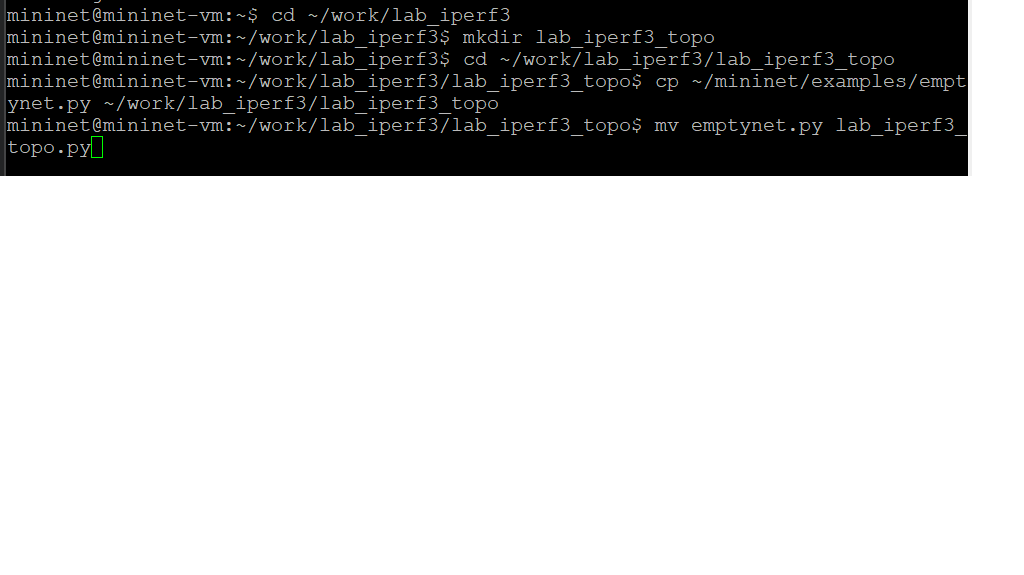

Подкаталог с примером скрипта

## Изучил содержание скрипта

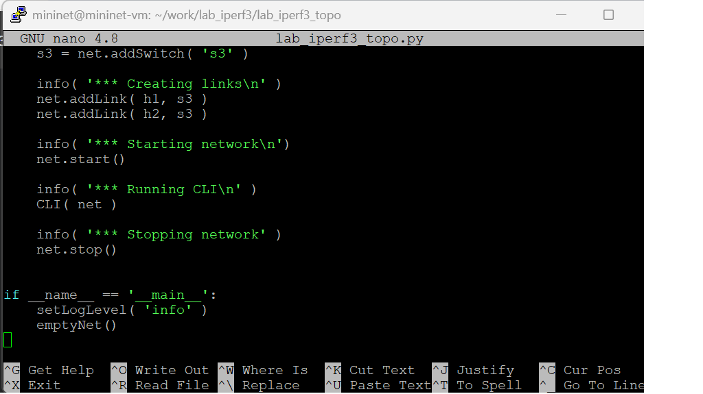

Содержание скрипта

## Зпаустил скрипт

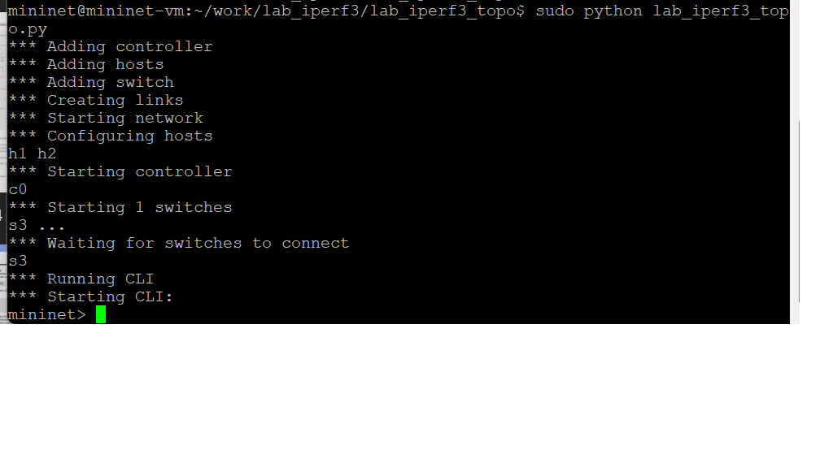

Запуск скрипта

## Посмотрел элементы топологии и завершил работу mininet

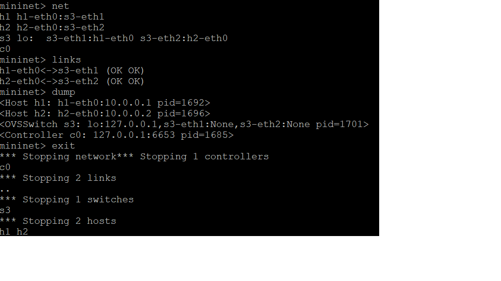

Элементы топологии

## Изменение, позволяющее вывести на экран информацию о хосте h1

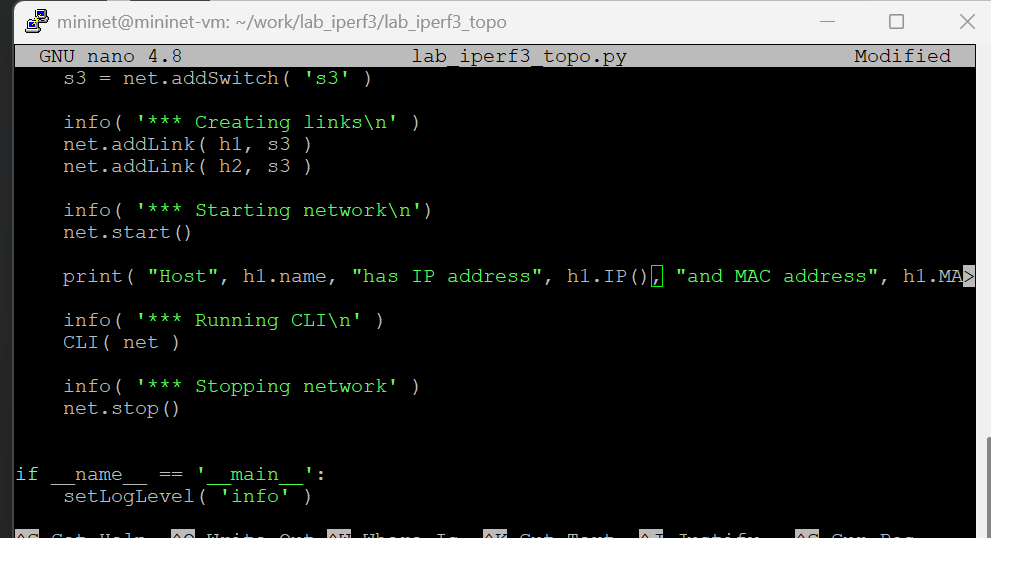

Вывд на экран информации о хосте h1

## Запуск нового скрипта

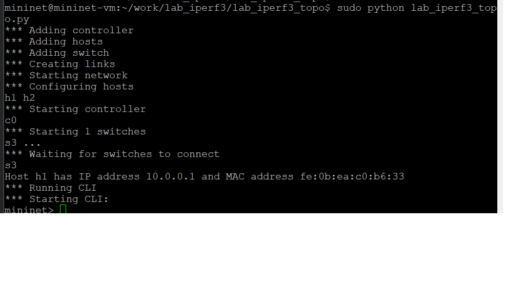

Запуск нового скрипта

## Изменил, чтобы выводилась информация об обоих хостах

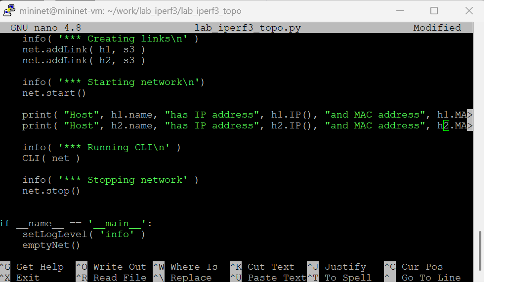

Информация об обоих хостах

## Запуск нового скрипта

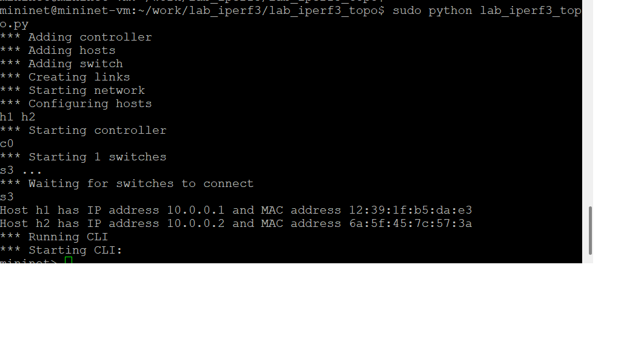

Запуск нового скрипта

## Сделал копию скрипта lab_iperf3_topo.py

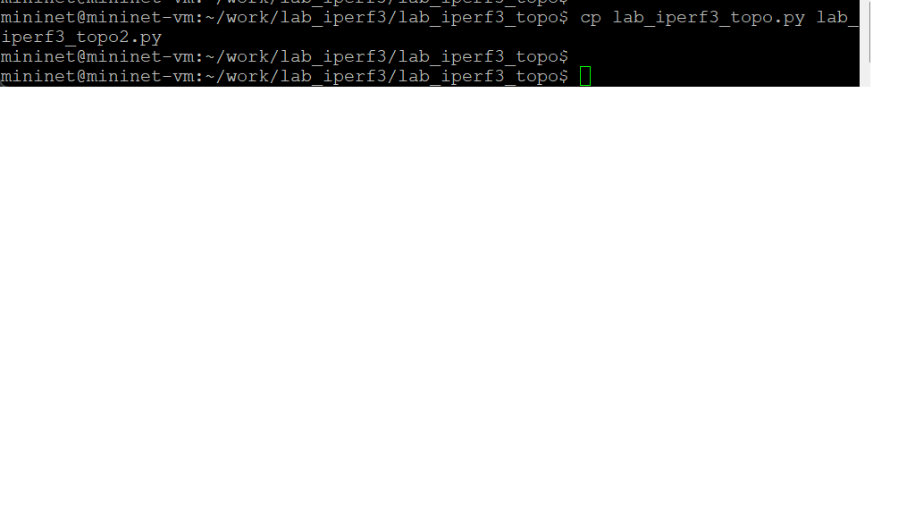

Копия скрипта lab_iperf3_topo.py

## Импорт классов, изменил описание сети, размер CPU и тд

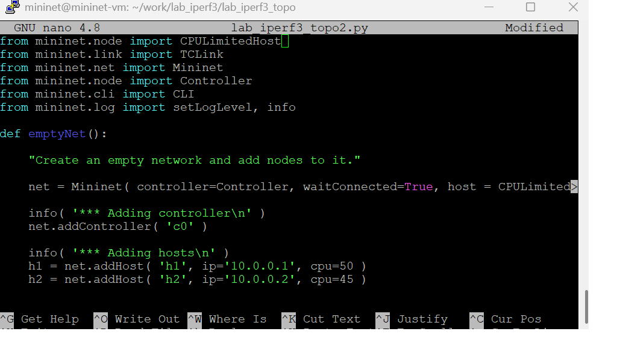

Импорт классов, описание сети, размер CPU и тд

## Запуск нового скрипта

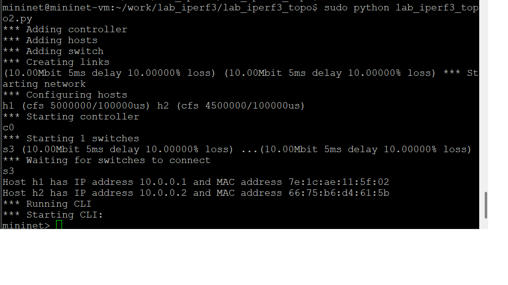

Запуск нового скрипта

## Анализ отчета

В lab_iperf3_topo2.py: - параметры линков: Отображаются характеристики (10.00Mbit 5ms delay 10.00000% loss) - конфигурация хостов: Подробная информация о CFS (Completely Fair Scheduler) Вывод: lab_iperf3_topo2.py показывает более детальную информацию о параметрах сети и планировщике, в то время как lab_iperf3_topo.py вывод упрощен

## Сделал копию скрипта lab_iperf3_topo2.py и поместил его в подкаталог iperf

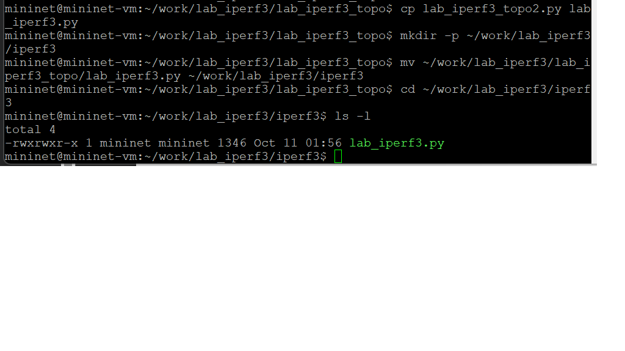

Копия скрипта lab_iperf3_topo2.py

## Заметка

Далее будут внесены след. имзенения: Хосты: Без ограничений CPU Каналы: 100 Мбит/с, задержка 75 мс, без потерь, без ограничителей iPerf3 тест: h2 запускает сервер iPerf3 h1 через 10 сек запускает клиент iPerf3 с сохранением в JSON

## Внес изменения в код

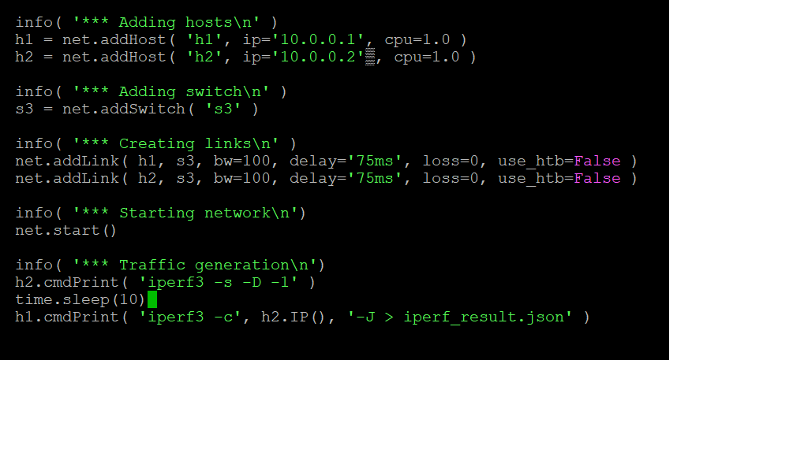

Изменения в коде

## Запуск скрипта

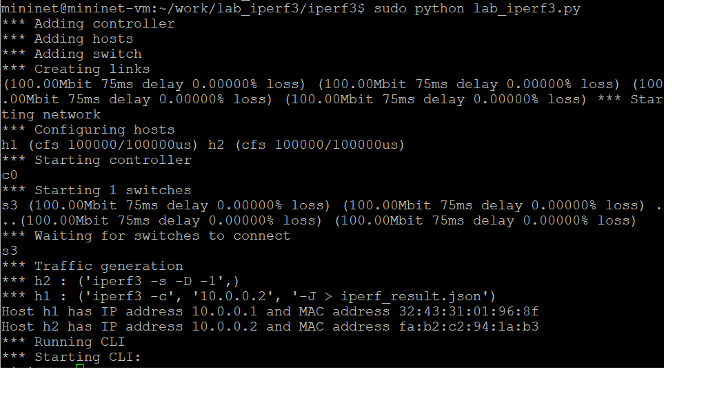

Запуск скрипта

## Анализ отчета

Характеристики каналов: - пропускная способность: 100 Мбит/с - задержка: 75 мс - потери: 0% (без потерь) Конфигурация хостов: - h1 и h2 - оба настроены с параметрами CFS (без ограничений CPU) Автоматический тест iperf3: - h2 запущен как сервер: iperf3 -s -D -1 - h1 запущен как клиент к 10.0.0.2 с сохранением в JSON

## Построил графики из получившегося JSON-файла

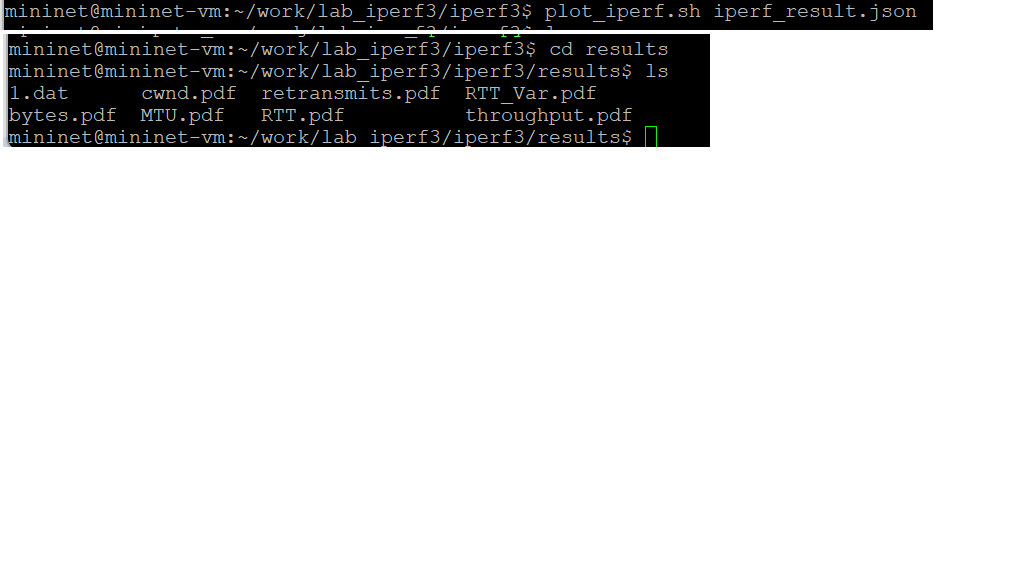

## Создал Makefile

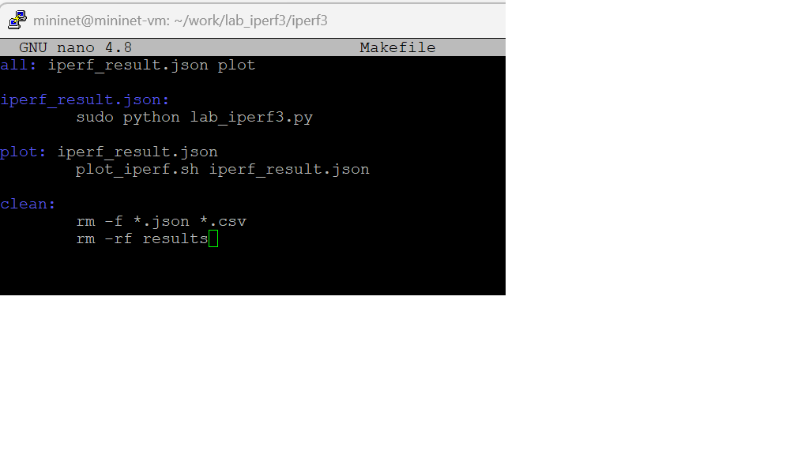

Makefile

## Проверка Makefile, все работает успешно

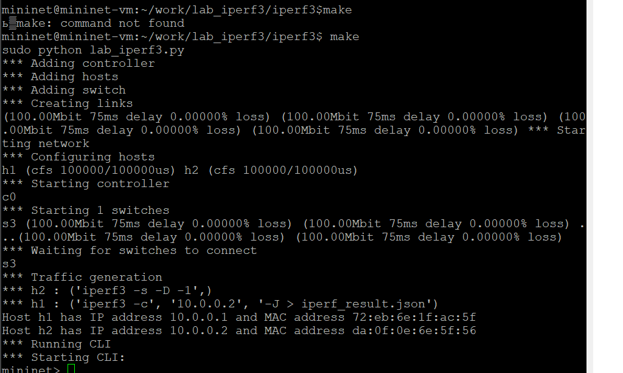

Проверка Makefile

## Выводы

Ознакомился с инструментом для измерения пропускной способности сети в режиме реального времени — iPerf3, а также получил навыки проведения воспроизводимого эксперимента по измерению пропускной способности моделируемой сети в среде Mininet.